# Population Demographics In Canada

Population Demographics In Canada

# Create Plotting Functions

```r
# Load libraries
library(dblogr) # devtools::install_github("derekmichaelwright/dblogr")
library(gganimate)
```

```r
gg_PopDem_plot <- function(areas = "Saskatchewan", years = 2019, trait = "Value", anim = F) {
  # Prep data
  my_ylab <- ifelse(trait == "Value", "Thousand People", "Percent")
  xx <- dblogr_STATCAN_Population_Demographics %>%
    select(1:6,7:27) %>%
    gather(Group, Value, 7:ncol(.)) %>%
    filter(Area %in% areas, Year %in% years) %>%
    mutate(Group = factor(Group, levels = unique(Group)),
           Percent = 100 * Value / `All ages`,
           Value = Value / 1000)
  # Plot
  mp <- ggplot(xx, aes(y = get(trait), x = Group, fill = Sex)) +
    geom_bar(data = xx %>% filter(Sex == "Males"), stat = "identity") +
    geom_bar(data = xx %>% filter(Sex == "Females"), stat = "identity", aes(y = -get(trait)))
  if(anim == F) { mp <- mp + facet_grid(Year~Area, scales = "free_x") }
  if(anim == T) { mp <- mp + facet_grid(.~Area, scales = "free_x") }
  mp + theme_dblogr(legend.position = "bottom") +
    labs(x = NULL, y = my_ylab,
         caption = "\xa9 www.dblogr.com/ | Data: www.statcan.ca/") +
    coord_cartesian(ylim = c(-max(xx$Value), max(xx$Value))) +
    coord_flip()
}
gg_PopDem_anim <- function(areas = c("Saskatchewan", "Alberta")) {
  gg_PopDem_plot(areas = areas, years = 1971:2019, anim = T) +
    # Here comes the gganimate specific bits
    labs(title = '{round(frame_time)}') +
    transition_time(Year) +
    ease_aes('linear')
}
gg_PopDem_years <- function(area = "Saskatchewan", year1 = 1971, year2 = 2019, trait = "Value") {
  # Prep data
  my_ylab <- ifelse(trait == "Value", "Thousand People", "Percent")
  xx <- dblogr_STATCAN_Population_Demographics %>%
    select(Area, Area_Short, Year, Sex, everything()) %>%
    select(1:6,7:27) %>%
    gather(Group, Value, 7:ncol(.)) %>%
    filter(Area %in% area, Year %in% c(year1, year2)) %>%
    mutate(Group = factor(Group, levels = unique(Group)),
           Percent = 100 * Value / `All ages`,
           Value = Value / 1000)
  # Plot
  ggplot(xx, aes(y = get(trait), x = Group, fill = Sex, lty = as.factor(Year))) +
    # year1
    geom_bar(data = xx %>% filter(Year == year1, Sex == "Males"),
             stat = "identity", alpha = 0.5, color = "black") +
    geom_bar(data = xx %>% filter(Year == year1, Sex == "Females"),
             stat = "identity", alpha = 0.5, color = "black", aes(y = -get(trait))) +
    # year2
    geom_bar(data = xx %>% filter(Year == year2, Sex == "Males"),
             stat = "identity", alpha = 0.5, color = "black") +
    geom_bar(data = xx %>% filter(Year == year2, Sex == "Females"),
             stat = "identity", alpha = 0.5, color = "black", aes(y = -get(trait))) +
    scale_linetype_manual(name = "Year", values = 0:1) +
    facet_grid(.~Area, scales = "free_x") +
    theme_dblogr(legend.position = "bottom") +
    guides(linetype = guide_legend(override.aes = list(fill = "grey70"))) +
    labs(x = NULL, y = my_ylab) +
    coord_cartesian(ylim = c(-max(xx[,trait]), max(xx[,trait]))) +
    coord_flip()
}
gg_PopDem_areas <- function(area1 = "Saskatchewan", area2 = "Ontario", years = 2019) {
  # Prep data
  xx <- dblogr_STATCAN_Population_Demographics %>%
    select(Area, Area_Short, Year, Sex, everything()) %>%
    select(1:6,7:27) %>%
    gather(Group, Value, 7:ncol(.)) %>%
    filter(Area %in% c(area1, area2), Year %in% years) %>%
    mutate(Area = factor(Area, levels = c(area2, area1)),
           Group = factor(Group, levels = unique(Group)),
           Percent = 100 * Value / `All ages`,
           Value = Value / 1000,
           my_lty = ifelse(Area == area1, "0", "1"))
  # Plot
  ggplot(xx, aes(y = Percent, x = Group, fill = Sex, lty = my_lty)) +
    # area1
    geom_bar(data = xx %>% filter(Area == area1, Sex == "Males"),
             stat = "identity", alpha = 0.5, color = "black") +
    geom_bar(data = xx %>% filter(Area == area1, Sex == "Females"),
             stat = "identity", alpha = 0.5, color = "black", aes(y = -Percent)) +
    # area2
    geom_bar(data = xx %>% filter(Area == area2, Sex == "Males"),
             stat = "identity", alpha = 0, color = "black") +
    geom_bar(data = xx %>% filter(Area == area2, Sex == "Females"),
             stat = "identity", alpha = 0, color = "black", aes(y = -Percent)) +
    scale_linetype_manual(name = "Area", values = 0:1, labels = c(area1, area2)) +
    facet_grid(.~Year, scales = "free_x") +
    theme_dblogr(legend.position = "bottom") +
    guides(linetype = guide_legend(override.aes = list(fill = "grey70"))) +
    labs(x = NULL, y = "Percent") +
    coord_cartesian(ylim = c(-max(xx$Value), max(xx$Value))) +
    coord_flip()
}
gg_PopDem_GenderRatio <- function(areas = NULL) {
  xx <- dblogr_STATCAN_Population_Demographics
  if(!is.null(areas)) { xx <- xx %>% filter(Area %in% areas) }
  xx <- xx %>% select(1:6,7:27) %>%
    gather(Group, Value, 7:ncol(.)) %>%
    mutate(Group = factor(Group, levels = unique(Group)),
           Value = Value / 1000) %>%
    filter(Year %in% 2019)
  xM <- xx %>% filter(Sex == "Males") %>% rename(Males=Value) %>% select(-Sex)
  xF <- xx %>% filter(Sex == "Females") %>% rename(Females=Value) %>% select(-Sex)
  xx <- left_join(xM, xF, by = c("Area", "Area_Short", "Year", "Group")) %>%
    mutate(Ratio = (Females / Males) - 1,
           `Gender Ratio` = ifelse(Ratio > 0, "More Females", "More Males"),
           Ratio = abs(Ratio))
  ggplot(xx, aes(x = Group, y = Ratio, fill = `Gender Ratio`)) +
    geom_bar(stat = "identity") +
    scale_y_continuous(breaks = 0:4, labels = c("1:1","2:1","3:1","4:1","5:1")) +
    facet_grid(. ~ Area) +
    theme_dblogr(legend.position = "top") +
    labs(y = NULL, x = NULL) +
    coord_flip()
}
```

# Canada

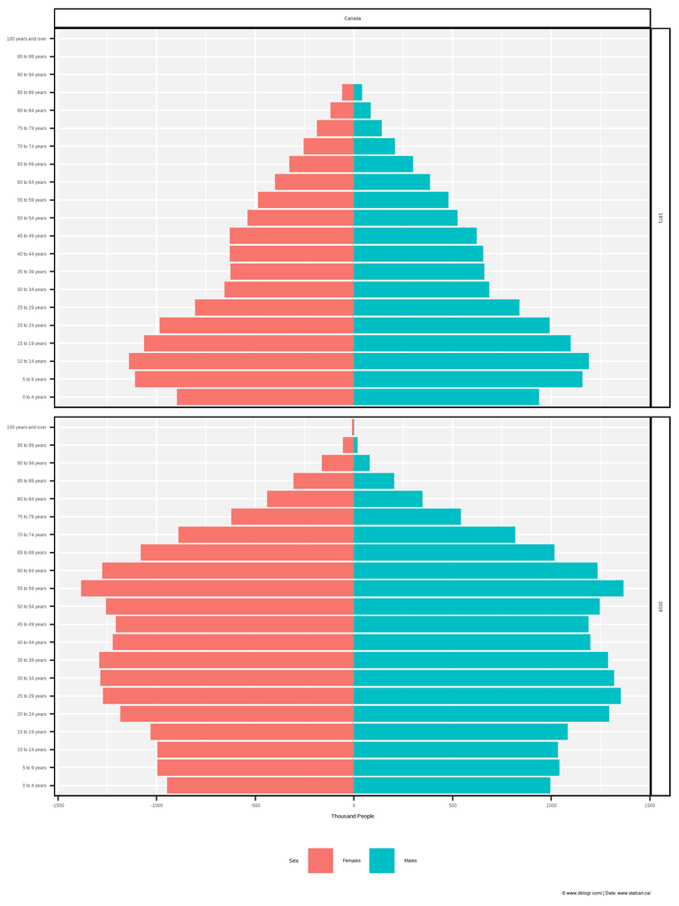

```r
mp <- gg_PopDem_plot("Canada", years = c(1971,2019))
ggsave("PopDem_plot_Canada.png", mp, width = 6, height = 8)
```

**Download Figure: Population Demographics in Canada (1971-2019)**

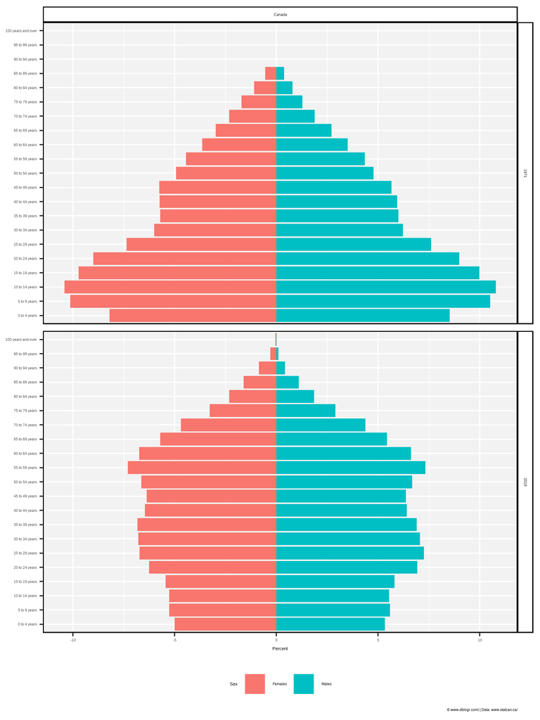

```r
mp <- gg_PopDem_plot("Canada", years = c(1971,2019), trait = "Percent")
ggsave("PopDem_percent_Canada.png", mp, width = 6, height = 8)
```

**Download Figure: Population Demographics in Canada (1971-2019)**

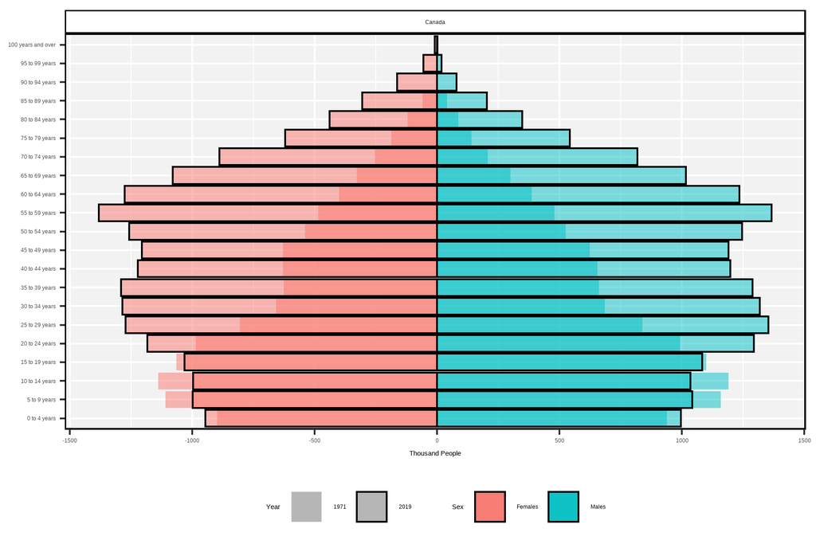

```r
mp <- gg_PopDem_years(area = "Canada", year1 = 1971, year2 = 2019)
ggsave("PopDem_years_Canada.png", mp, width = 6, height = 4)
```

**Download Figure: Population Demographics in Canada (1971-2019)**

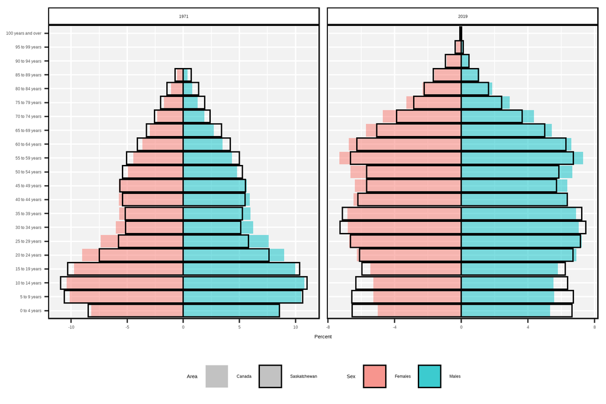

```r
mp <- gg_PopDem_areas(area1 = "Canada", area2 = "Saskatchewan", years = c(1971,2019))
ggsave("PopDem_areas_Canada_Sask.png", mp, width = 6, height = 4)
```

**Download Figure: Population Demographics in Canada vs Saskatchewan (1971-2019)**

```r
mp <- gg_PopDem_anim("Canada")
anim_save("Population_Demographics_Canada.gif", mp, width = 600, height = 400)
```

# Saskatchewan

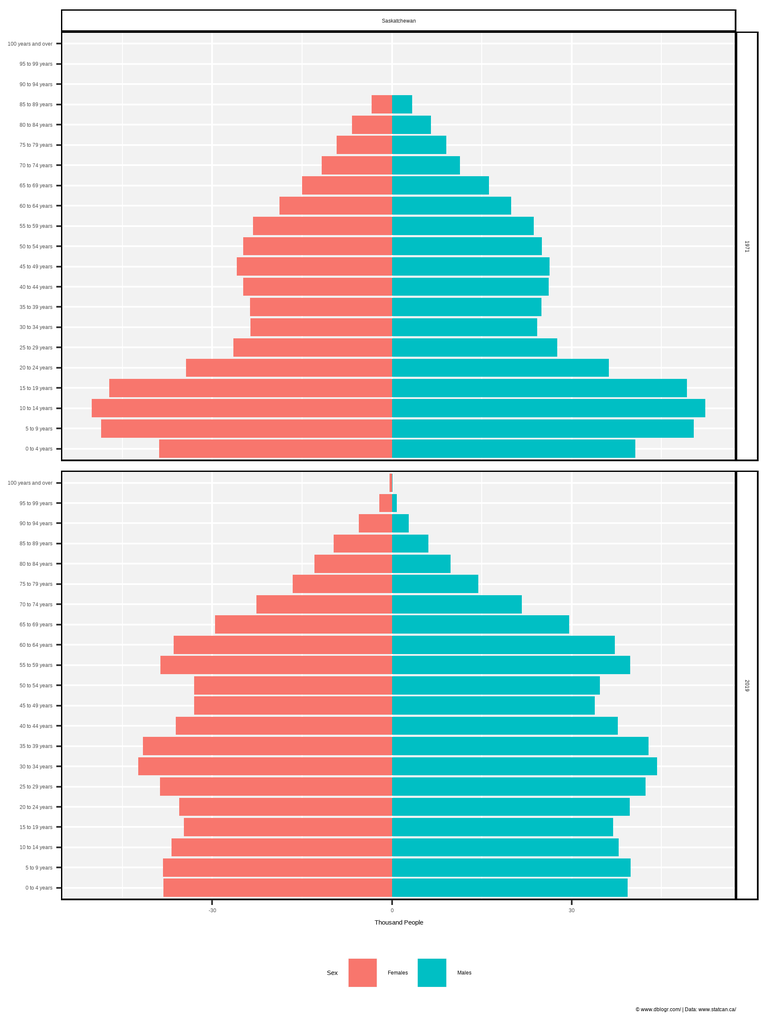

```r
mp <- gg_PopDem_plot("Saskatchewan", years = c(1971,2019))
ggsave("PopDem_plot_Saskatchewan.png", mp, width = 6, height = 8)
```

**Download Figure: Population Demographics in Saskatchewan (1971-2019)**

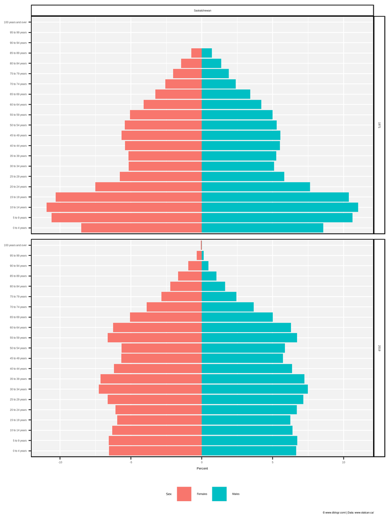

```r
mp <- gg_PopDem_plot("Saskatchewan", years = c(1971,2019), trait = "Percent")
ggsave("PopDem_percent_Saskatchewan.png", mp, width = 6, height = 8)
```

**Download Figure: Population Demographics in Saskatchewan (1971-2019)**

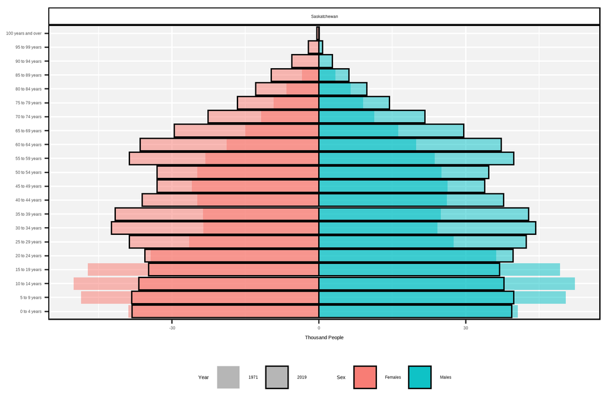

```r
mp <- gg_PopDem_years(area = "Saskatchewan", year1 = 1971, year2 = 2019)
ggsave("PopDem_years_Saskatchewan.png", mp, width = 6, height = 4)
```

**Download Figure: Population Demographics in Saskatchewan (1971-2019)**

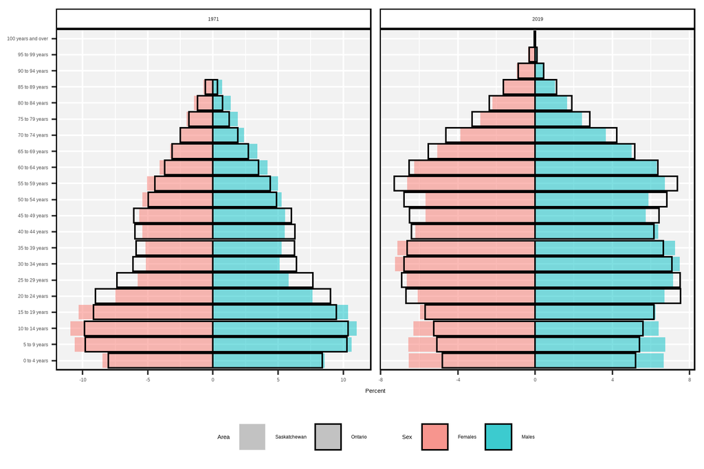

```r
mp <- gg_PopDem_areas(area1 = "Saskatchewan", area2 = "Ontario", years = c(1971,2019))
ggsave("PopDem_areas_Sask_Ontario.png", mp, width = 6, height = 4)
```

**Download Figure: Population Demographics in Saskatchewan vs Ontario (1971-2019)**

```r
mp <- gg_PopDem_anim("Saskatchewan")
anim_save(paste0("Population_Demographics_Saskatchewan.gif"), mp, width = 600, height = 400)
```

# Alberta

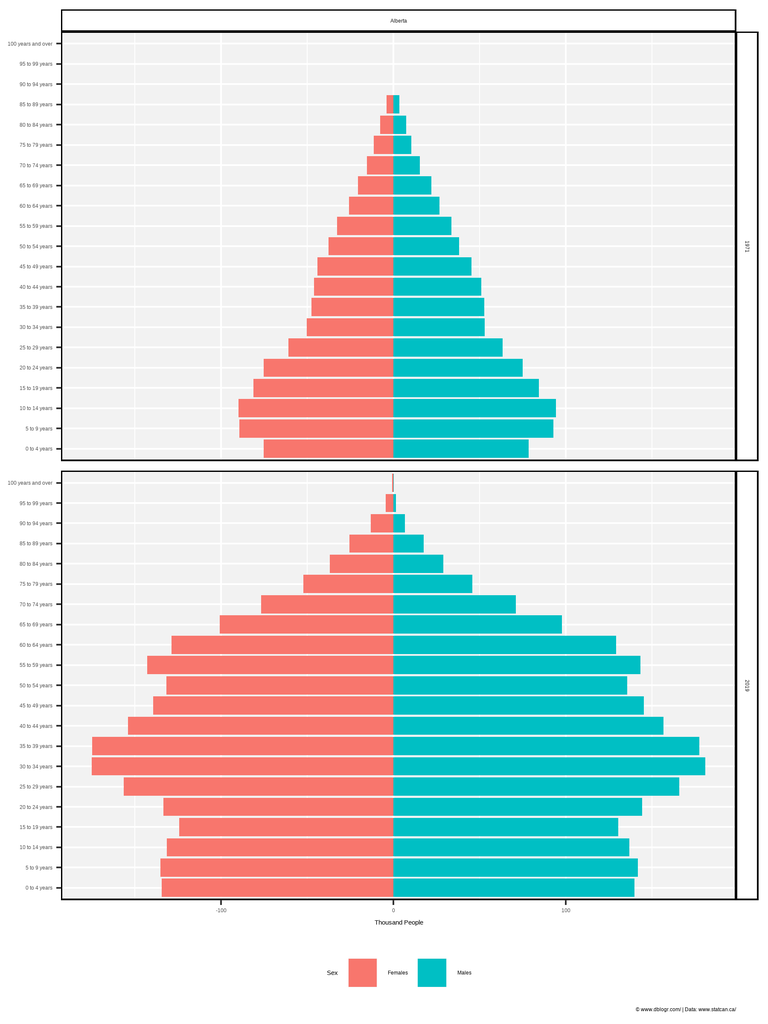

```r
mp <- gg_PopDem_plot("Alberta", years = c(1971,2019))
ggsave("PopDem_plot_Alberta.png", mp, width = 6, height = 8)
```

**Download Figure: Population Demographics in Alberta (1971-2019)**

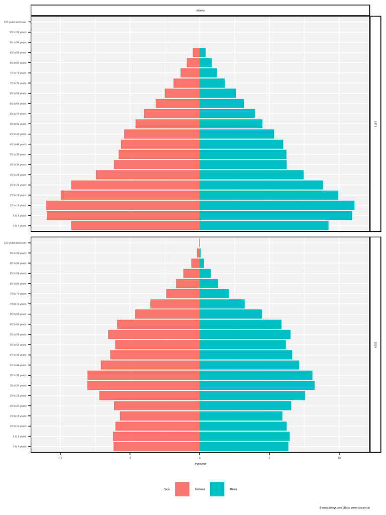

```r
mp <- gg_PopDem_plot("Alberta", years = c(1971,2019), trait = "Percent")
ggsave("PopDem_percent_Alberta.png", mp, width = 6, height = 8)
```

**Download Figure: Population Demographics in Alberta (1971-2019)**

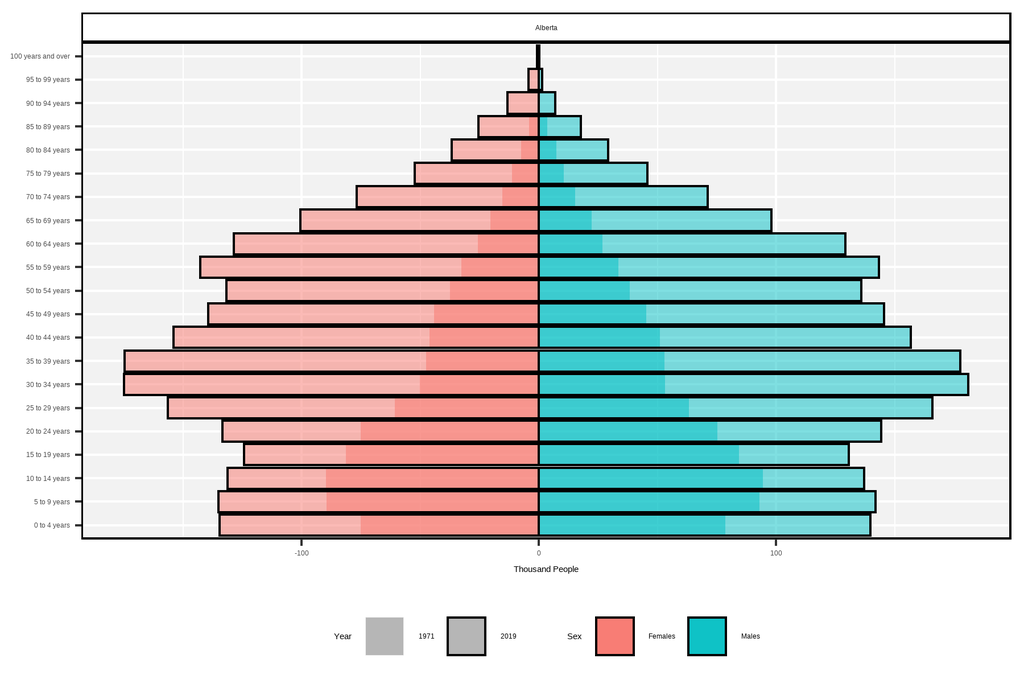

```r
mp <- gg_PopDem_years(area = "Alberta", year1 = 1971, year2 = 2019)
ggsave("PopDem_years_Alberta.png", mp, width = 6, height = 4)
```

**Download Figure: Population Demographics in Alberta (1971-2019)**

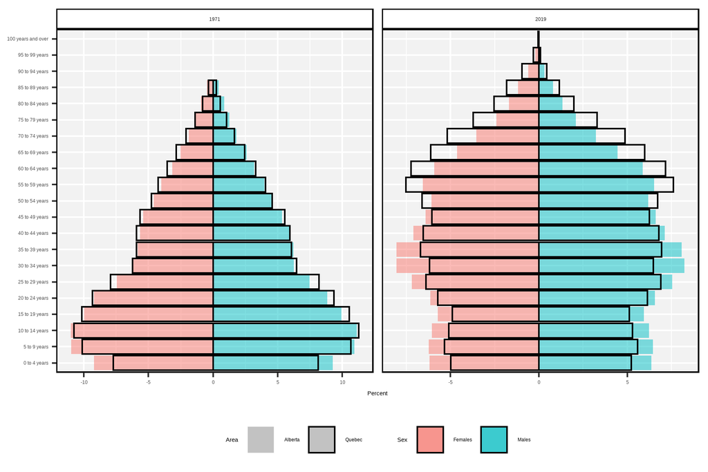

```r
mp <- gg_PopDem_areas(area1 = "Alberta", area2 = "Quebec", years = c(1971,2019))
ggsave("PopDem_areas_Alberta_Quebec.png", mp, width = 6, height = 4)
```

**Download Figure: Population Demographics in Alberta vs Quebec (1971-2019)**

```r
mp <- gg_PopDem_anim("Alberta")
anim_save(paste0("Population_Demographics_Alberta.gif"), mp, width = 600, height = 400)
```

# Eastern Canada

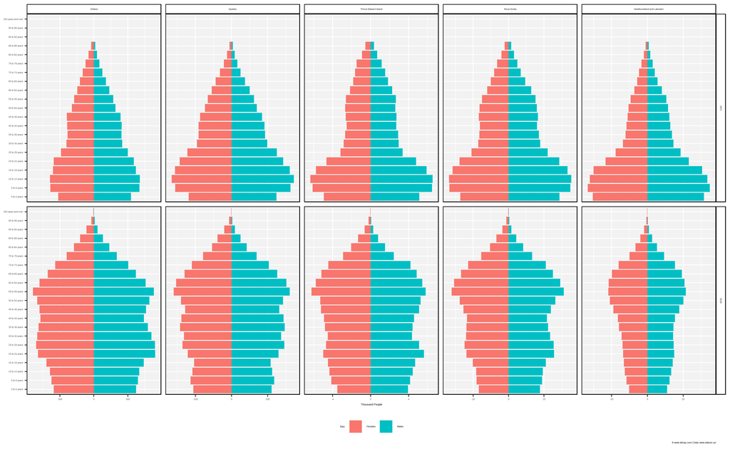

```r
mp <- gg_PopDem_plot(c("Ontario", "Quebec"," New Brunswick", "Nova Scotia",
                  "Prince Edward Island", "Newfoundland and Labrador"),
                years = c(1971,2019))
ggsave("PopDem_2019_CanadaEastern.png", mp, width = 13, height = 8)
```

**Download Figure: Population Demographics in Eastern Canada (1971-2019)**

# Western Canada

[figure not shown]

```r
mp <- gg_PopDem_plot(c("British Columbia", "Alberta"," Saskatchewan", "Manitoba",
                  "Yukon", "Northwest Territories", "Nunavut"),
                years = c(1975,2019))
ggsave("PopDem_2019_CanadaWestern.png", mp, width = 15, height = 8)
```

# West Vs East

[figure not shown]

```r
provs <- c("British Columbia", "Alberta"," Saskatchewan", "Manitoba",
           "Yukon", "Northwest Territories", "Nunavut")
x1 <- dblogr_STATCAN_Population_Demographics %>%
  filter(Sex == "Both sexes", Area == "Canada") %>%
  select(Year, Canada=`All ages`)
xx <- dblogr_STATCAN_Population_Demographics %>%
  filter(Sex == "Both sexes", Area != "Canada") %>%
  mutate(SubRegion = ifelse(Area %in% provs, "Western Canada", "Eastern Canada"),
         SubRegion = factor(SubRegion, levels = c("Western Canada", "Eastern Canada"))) %>%
  group_by(Year, SubRegion) %>%
  summarise(Population = sum(`All ages`, na.rm = T)) %>%
  left_join(x1, by = "Year") %>%
  mutate(Percent = round(100 * Population / Canada, 1),
         Population = round(Population / 1000000, 1))
x2 <- xx %>% filter(Year == 2019)
mp1 <- ggplot(xx, aes(x = Year, y = Population, color = SubRegion)) +
  geom_line() +
  scale_color_manual(values = c("darkred","darkblue")) +
  scale_y_continuous(breaks = seq(5,25,5),
                     sec.axis = sec_axis(~., breaks = x2$Population)) +
  coord_cartesian(xlim = c(1972,2018)) +
  facet_grid(.~"Million People") +
  theme_dblogr(rotx = T) +
  labs(y = NULL, x = NULL)
mp2 <- ggplot(xx, aes(x = Year, y = Percent, color = SubRegion)) +
  geom_line() +
  scale_color_manual(values = c("darkred","darkblue")) +
  scale_y_continuous(sec.axis = sec_axis(~., breaks = x2$Percent)) +
  coord_cartesian(xlim = c(1972,2018)) +
  facet_grid(.~"Percent of Population") +
  theme_dblogr(rotx = T) +
  labs(y = NULL, x = NULL)
mp <- ggpubr::ggarrange(mp1, mp2, ncol = 2, common.legend = T)
ggsave("PopDem_WestVsEast.png", mp, width = 6, height = 4)
```

**Download Figure: Population of Western and Eastern Canada**

# Median Age

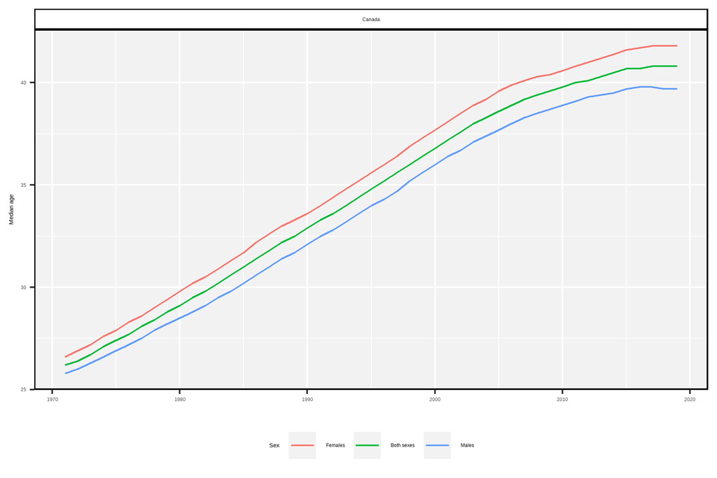

```r
xx <- dblogr_STATCAN_Population_Demographics %>% filter(Area == "Canada") %>%
  mutate(Sex = factor(Sex, levels = c("Females", "Both sexes", "Males")))
mp <- ggplot(xx, aes(Year, y = `Median age`, color = Sex)) + geom_line() +
  facet_grid(.~Area) +
  theme_dblogr(legend.position = "bottom") +
  labs(x = NULL)
ggsave("PopDem_MedianAge_Canada.png", mp, width = 6, height = 4)
```

**Download Figure: Median Age of Men and Women in Canada (1971-2019)**

# Gender Ratio

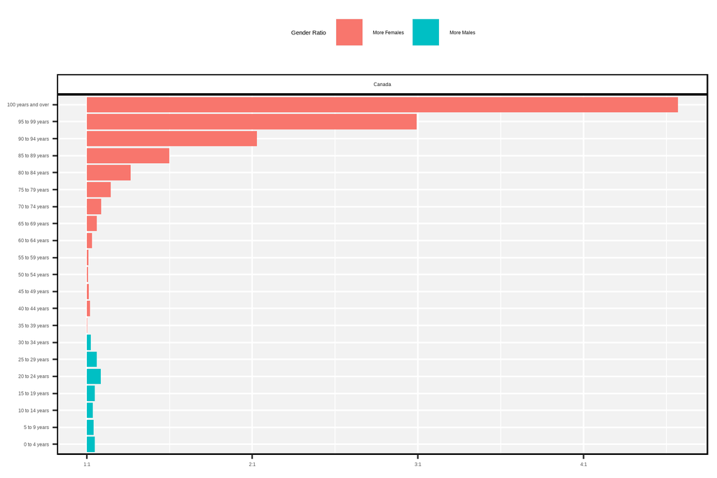

```r
mp <- gg_PopDem_GenderRatio(areas = "Canada")
ggsave("PopDem_genderRatio_Canada.png", mp, width = 6, height = 4)
```

**Download Figure: Canadian Gender Ratio Among Age Groups**

[figure not shown]

```r
provs <- unique(dblogr_STATCAN_Population_Demographics$Area)
mp <- gg_PopDem_GenderRatio()
ggsave("PopDem_genderRatio_Provinces.png", mp, width = 20, height = 4)
```

**Download Figure: Gender Ratio Among Age Groups and Provinces**